# Lab 6: Statistics

Z-Tests, Z-Scores, and the Standard Normal Distribution

In this lab, we dive into Z-tests, Z-scores, and the standard normal distribution. We use these tools to analyze life expectancy data, comparing Latin American countries to global averages and creating visualizations to better understand our findings. By performing Z-tests, we can test hypotheses about the equality of means, and through standardization, we convert our data to a standard normal distribution to simplify our analysis.

Z-Tests

Z-Scores

Standard Normal Distribution

Author

Bogdan G. Popescu

# 1 Intro

Open a new Quarto document. Select all text by pressing Ctrl + A (Windows) or Cmd + A (Mac), then press Delete. Next, copy and paste the following preamble.

```yaml
---
title: "Lab 6"
author: "Your Name"
date: "September 13, 2024"
format:
  html:
    toc: true
    number-sections: true
    colorlinks: true
    smooth-scroll: true
    embed-resources: true
---
```

Render the document and save it under “week6” in your “stats” folder.

# 2 Z-Tests

```r
#Removing previous datasets in memory
rm(list = ls())
#Loading the relevant libraries
library(ggplot2)
library(gridExtra)
library(dplyr)
library(BSDA)
```

We learned from the lecture that Z-tests evaluate if the averages of two datasets are different from each other when standard deviation or variance is known. The sample size typically should be larger than 30. To illustrate how Z-tests work, let us go back to the sample of Latin American countries and compare them to the world.

## 2.1 Loading the Data

If you don’t have the Life Expectancy dataset, anymore, you can download it from the following link:

- [Life expectancy data](https://www.dropbox.com/s/k8pwn5x0mechewy/life-expectancy.csv?dl=0)

Let us re-examine the distribution of our life expectancy dataset by making a histogram. We need to first load the data:

```r
#Setting path
setwd("/Users/bgpopescu/Dropbox/john_cabot/teaching/stats/week6/lab/")
#Step1: Loading the data
life_expectancy_df <- read.csv(file = './data/life-expectancy.csv')
```

## 2.2 Cleaning the Data

In the next few lines we average life expectancy over country (the oiriginal dataset is a panel - with countries and years). This means that we are getting rid of the time component.

```r
#Step1: Calculating the mean
life_expectancy_df2<-life_expectancy_df%>%
  dplyr::group_by(Entity, Code)%>%
  dplyr::summarize(life_exp_mean=mean(Life.expectancy.at.birth..historical.))

#Step2: Cleaning the Data
weird_labels <- c("OWID_KOS", "OWID_WRL", "")
clean_life_expectancy_df<-subset(life_expectancy_df2, !(Code %in% weird_labels))
```

## 2.3 Inspecting the data

Let us inspect the first 10 entries.

```r
head(clean_life_expectancy_df, n=10)
```

| Entity | Code | life_exp_mean |
| --- | --- | --- |
| Afghanistan | AFG | 45.38333 |
| Albania | ALB | 68.28611 |
| Algeria | DZA | 57.53013 |
| American Samoa | ASM | 68.63750 |
| Andorra | AND | 77.04861 |
| Angola | AGO | 45.08466 |
| Anguilla | AIA | 69.44028 |
| Antigua and Barbuda | ATG | 71.20972 |
| Argentina | ARG | 65.40805 |
| Armenia | ARM | 67.15694 |

## 2.4 Sorting the dataframe in the order of life_expectancy

Let us now order our dataset based on life expectancy.

```r
clean_life_expectancy_sorted_df<-clean_life_expectancy_df[order(-clean_life_expectancy_df$life_exp_mean),]
head(clean_life_expectancy_sorted_df, n=10)
```

| Entity | Code | life_exp_mean |
| --- | --- | --- |
| Monaco | MCO | 77.25278 |
| Andorra | AND | 77.04861 |
| San Marino | SMR | 76.88056 |
| Guernsey | GGY | 76.71944 |
| Israel | ISR | 75.49722 |
| Vatican | VAT | 75.33194 |
| Hong Kong | HKG | 75.33056 |
| Jersey | JEY | 75.20278 |
| New Zealand | NZL | 75.13473 |
| Gibraltar | GIB | 75.04167 |

## 2.5 Make a barplot for the first 10 countries

Let us now make a barplot where life expectancy is ordered from highest to lowest. The first step entails selecting the top 10 countries.

```r
life_exp_top10<-head(clean_life_expectancy_sorted_df, n=10)
life_exp_top10
```

| Entity | Code | life_exp_mean |
| --- | --- | --- |
| Monaco | MCO | 77.25278 |
| Andorra | AND | 77.04861 |
| San Marino | SMR | 76.88056 |
| Guernsey | GGY | 76.71944 |
| Israel | ISR | 75.49722 |
| Vatican | VAT | 75.33194 |
| Hong Kong | HKG | 75.33056 |
| Jersey | JEY | 75.20278 |
| New Zealand | NZL | 75.13473 |
| Gibraltar | GIB | 75.04167 |

Let us know create the barplot for the first 10 entries:

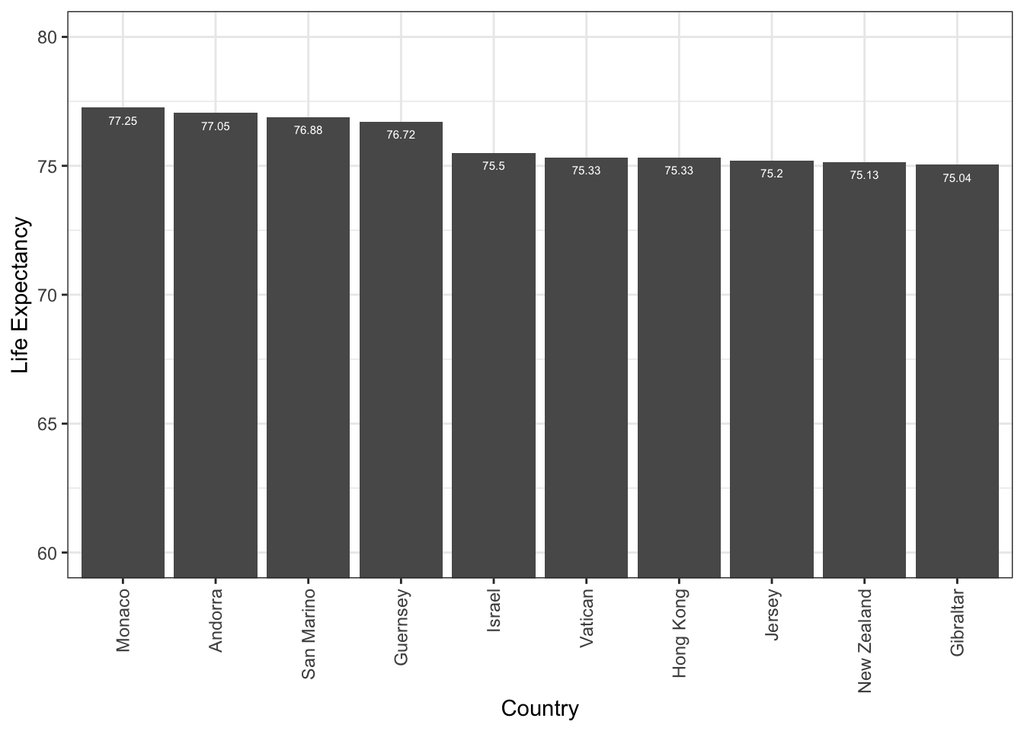

```r
figure_1<-ggplot(life_exp_top10, aes(x = reorder(Entity, -life_exp_mean),
                                     y = life_exp_mean)) +
  geom_bar(stat="identity")+
  coord_cartesian(ylim = c(60,80))+
  geom_text(data=life_exp_top10,
  aes(label = round(life_exp_mean,2),
        y = life_exp_mean,
        vjust = 2),
  colour = "white", size=2)+
  xlab("Country") + ylab("Life Expectancy")+
  theme_bw()+
  theme(axis.text.x = element_text(angle = 90, vjust = 0.5, hjust=1))

figure_1
```

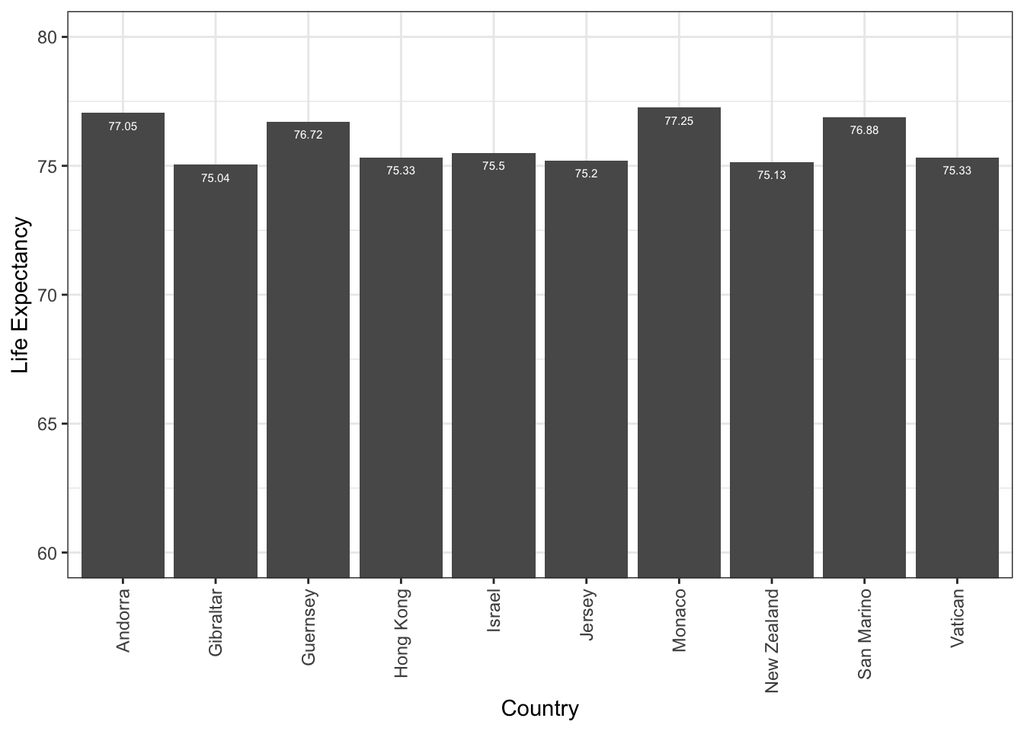

```r
figure_1<-ggplot(life_exp_top10, aes(x = Entity,
                                     y = life_exp_mean)) +
  geom_bar(stat="identity")+
  coord_cartesian(ylim = c(60,80))+
  geom_text(data=life_exp_top10,
  aes(label = round(life_exp_mean,2),
        y = life_exp_mean,
        vjust = 2),
  colour = "white", size=2)+
  xlab("Country") + ylab("Life Expectancy")+
  theme_bw()+
  theme(axis.text.x = element_text(angle = 90, vjust = 0.5, hjust=1))

figure_1
```

This is how we select the countries in Latin America.

```r
#Step3: Selecting the Latin American countries
latam_countries<-c("Belize",
                   "Costa Rica",
                   "El Salvador",
                   "Guatemala",
                   "Honduras",
                   "Mexico",
                   "Nicaragua",
                   "Panama",
                   "Argentina",
                   "Bolivia",
                   "Brazil",
                   "Chile",
                   "Colombia",
                   "Ecuador",
                   "Guyana",
                   "Paraguay",
                   "Peru",
                   "Suriname",
                   "Uruguay",
                   "Venezuela",
                   "Cuba",
                   "Dominican Republic",
                   "Haiti")

latam_countries_df<-subset(clean_life_expectancy_df, (Entity %in% latam_countries))
head(latam_countries_df, n=10)
```

| Entity | Code | life_exp_mean |
| --- | --- | --- |
| Argentina | ARG | 65.40805 |
| Belize | BLZ | 65.96528 |
| Bolivia | BOL | 52.58974 |
| Brazil | BRA | 61.08718 |
| Chile | CHL | 63.30230 |
| Colombia | COL | 63.05550 |
| Costa Rica | CRI | 68.69115 |
| Cuba | CUB | 67.24590 |
| Dominican Republic | DOM | 61.05733 |
| Ecuador | ECU | 64.96389 |

```r
#Ordering countries based on the life expectancy values
life_exp_top10_latam<-latam_countries_df[order(-latam_countries_df$life_exp_mean),]
#Selecting only the first 10
life_exp_top10_latam<-head(life_exp_top10_latam, n=10)
life_exp_top10_latam
```

| Entity | Code | life_exp_mean |
| --- | --- | --- |
| Uruguay | URY | 70.76364 |
| Costa Rica | CRI | 68.69115 |
| Panama | PAN | 68.40811 |
| Cuba | CUB | 67.24590 |
| Belize | BLZ | 65.96528 |
| Argentina | ARG | 65.40805 |
| Ecuador | ECU | 64.96389 |
| Venezuela | VEN | 64.84935 |
| Paraguay | PRY | 63.74872 |
| Chile | CHL | 63.30230 |

Let us create a barplot for the top 10 countries in Latin America:

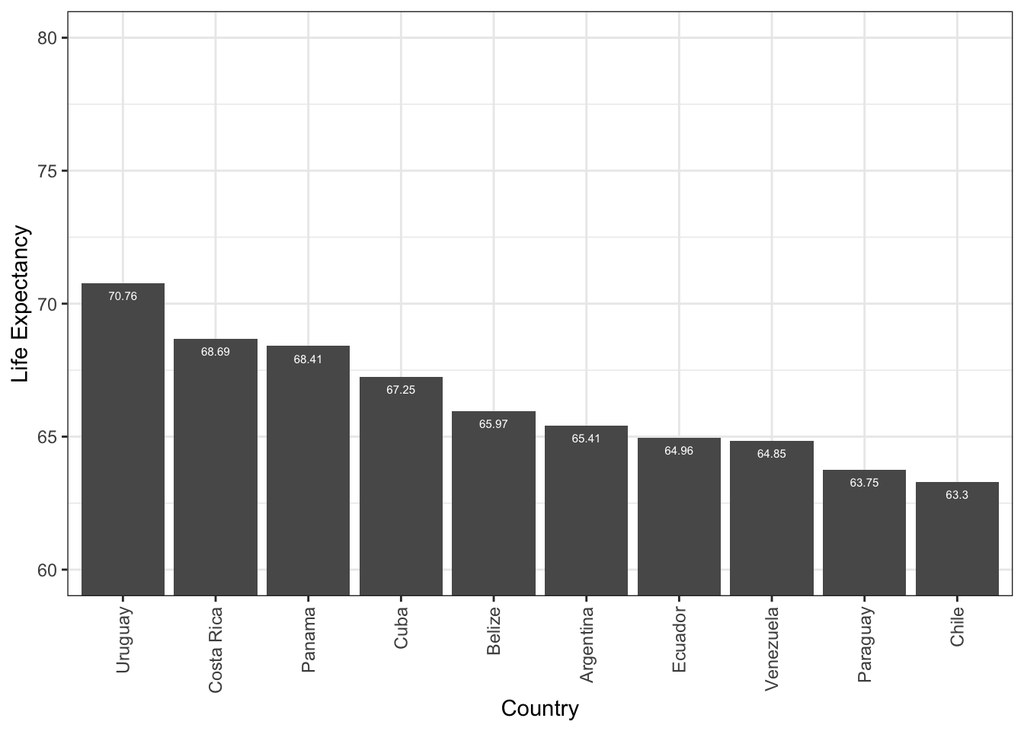

```r
figure_2<-ggplot(life_exp_top10_latam, aes(x = reorder(Entity, -life_exp_mean),
                                           y = life_exp_mean)) +
  geom_bar(stat="identity")+
  coord_cartesian(ylim = c(60,80))+
  geom_text(data=life_exp_top10_latam,
  aes(label = round(life_exp_mean,2),
        y = life_exp_mean,
        vjust = 2),
  colour = "white", size=2)+
  xlab("Country") + ylab("Life Expectancy")+
  theme_bw()+
  theme(axis.text.x = element_text(angle = 90, vjust = 0.5, hjust=1))

figure_2
```

Let us now recreate the two graphs and add them together using grid.arrange.

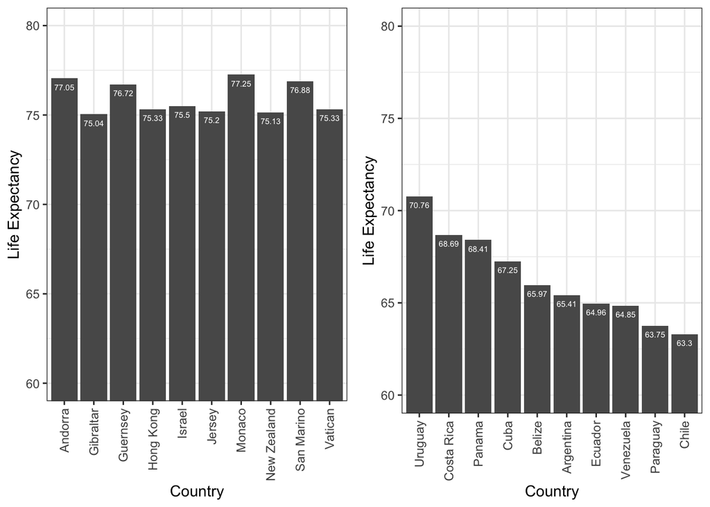

```r
grid.arrange(figure_1, figure_2, ncol=2)
```

A few things could help:

- remove the Y-axis label from the second graph
- Add descriptive titles

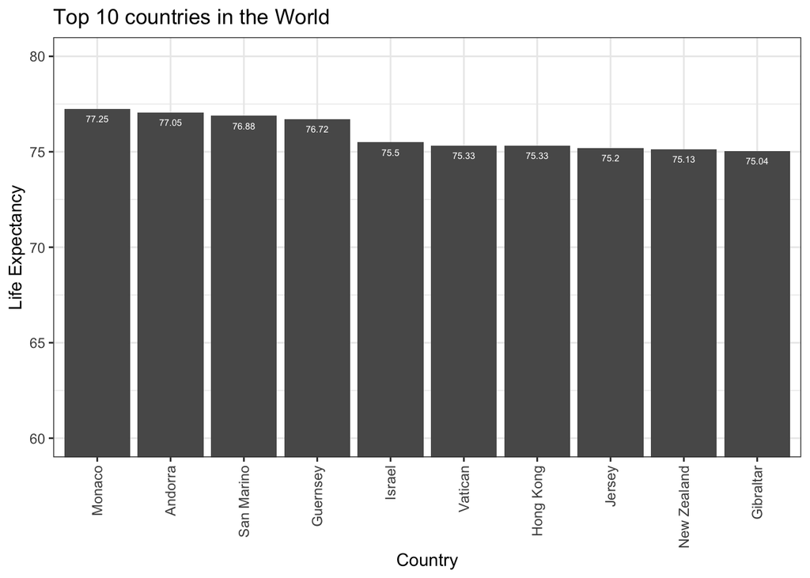

```r
figure_3<-ggplot(life_exp_top10, aes(x = reorder(Entity, -life_exp_mean), y = life_exp_mean)) +
  geom_bar(stat="identity")+
  coord_cartesian(ylim = c(60,80))+
  geom_text(data=life_exp_top10,
  aes(label = round(life_exp_mean,2),
        y = life_exp_mean,
        vjust = 2),
  colour = "white", size=2)+
  xlab("Country") + ylab("Life Expectancy")+
  theme_bw()+
  theme(axis.text.x = element_text(angle = 90, vjust = 0.5, hjust=1))+
  #adding a title
  ggtitle("Top 10 countries in the World")
figure_3
```

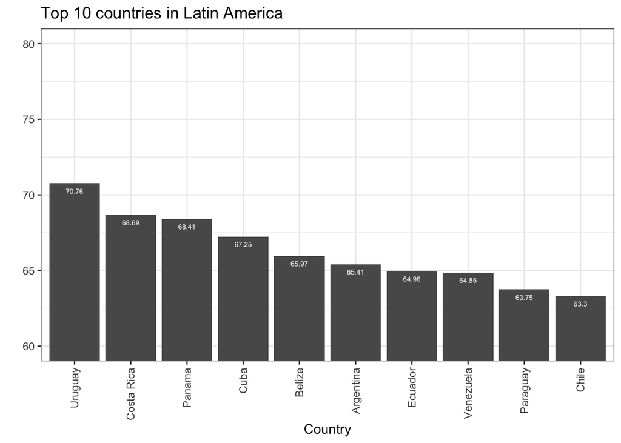

```r
figure_4<-ggplot(life_exp_top10_latam, aes(x = reorder(Entity, -life_exp_mean), y = life_exp_mean)) +
  geom_bar(stat="identity")+
  coord_cartesian(ylim = c(60,80))+
  geom_text(data=life_exp_top10_latam,
  aes(label = round(life_exp_mean,2),
        y = life_exp_mean,
        vjust = 2),
  colour = "white", size=2)+
  #removing the y label
  xlab("Country") + ylab("")+
  theme_bw()+
  theme(axis.text.x = element_text(angle = 90, vjust = 0.5, hjust=1))+
  #adding a title
  ggtitle("Top 10 countries in Latin America")
figure_4
```

Let us now put them side by side

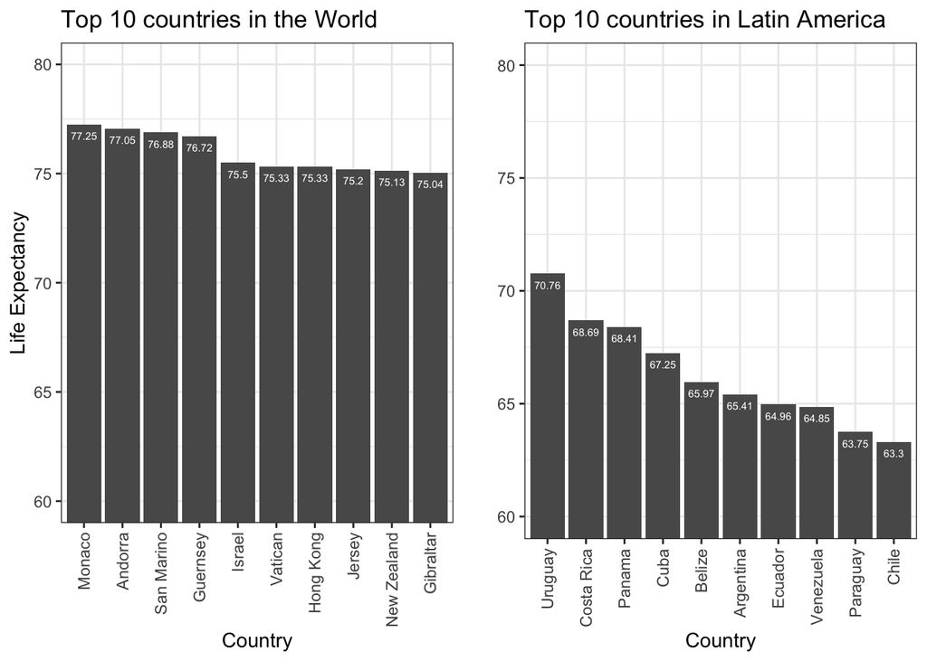

```r
grid.arrange(figure_3, figure_4, ncol=2)
```

This looks much better.

# 3 Problem

Now we can finally ask the question: Is the mean life expectancy in Latin America equal to the population life expectancy? What kind of test do we perform?

**Answer**: Two-tailed z-test. This is because we are asking if something is “EQUAL” to something else.

What do we need to perform a z-test?

We need the following:

- Population Mean $\mu$
- Population SD $\sigma$
- Sample Mean for Latam: $\bar{X}$
- Sample size for Latam: n

Population Mean $\mu$ is: 61.934159  
Population SD $\sigma$ is: 8.68723  
Sample Mean for Latam $\bar{X}$ is 61.9140352  
Sample size for Latam n is 23

How do we know this?

```r
mean_population<-mean(clean_life_expectancy_df$life_exp_mean)
sd_population<-sd(clean_life_expectancy_df$life_exp_mean)
mean_latam<-mean(latam_countries_df$life_exp_mean)
sample_size_latam<-nrow(latam_countries_df)

mean_population
```

```
[1] 61.93416
```

```r
sd_population
```

```
[1] 8.68723
```

```r
mean_latam
```

```
[1] 61.91404
```

```r
sample_size_latam
```

```
[1] 23
```

We can finally perform a z-test following the formula:

$$Z_{obs}=\frac{\bar{X}-\mu}{\frac{\sigma}{\sqrt{n}}}$$
We now simply calculate the $Z_{obs}$.

```r
z_obs<-(mean_latam-mean_population)/(sd_population/sqrt(sample_size_latam))
z_obs
```

```
[1] -0.01110945
```

The same score can be obtained if we do the following:

```r
z_obs2<-BSDA::z.test(latam_countries_df$life_exp_mean,
                     mu=mean_population, sigma.x=sd_population,
                     alternative = "two.sided")
z_obs2
```

```
    One-sample z-Test

data:  latam_countries_df$life_exp_mean
z = -0.011109, p-value = 0.9911
alternative hypothesis: true mean is not equal to 61.93416
95 percent confidence interval:
 58.36373 65.46434
sample estimates:
mean of x
 61.91404
```

Note that we define whether this is a one-tailed or a two-tailed z-test by using the option `two.sided` in `alternative`.

The Null Hypothesis - $H_0$: The sample mean (for Latam) is equal to the population mean.

The Alternative Hypothesis - $H_1$: The sample mean (for Latam) is NOT equal to the population mean.  
Note that this is also specified in the test itself: “alternative hypothesis: true mean is not equal to 61.93416”

Do we accept or reject the $H_0$?

We do not reject the null hypothesis (H0) because p ≥ 0.05 and conclude that there is no significant difference between the means of the two groups: Latam and the population mean.

This is easier to see by doing a boxplot.

```r
#Creating a new dataframe
clean_life_expectancy_df_continent<-clean_life_expectancy_df
#Adding a new variable, called sample
clean_life_expectancy_df_continent$sample<-"Rest"
#Labeling Latin America
clean_life_expectancy_df_continent$sample[clean_life_expectancy_df_continent$Entity %in% latam_countries]<-"Latam"

unique(clean_life_expectancy_df_continent$sample)
```

```
[1] "Rest"  "Latam"
```

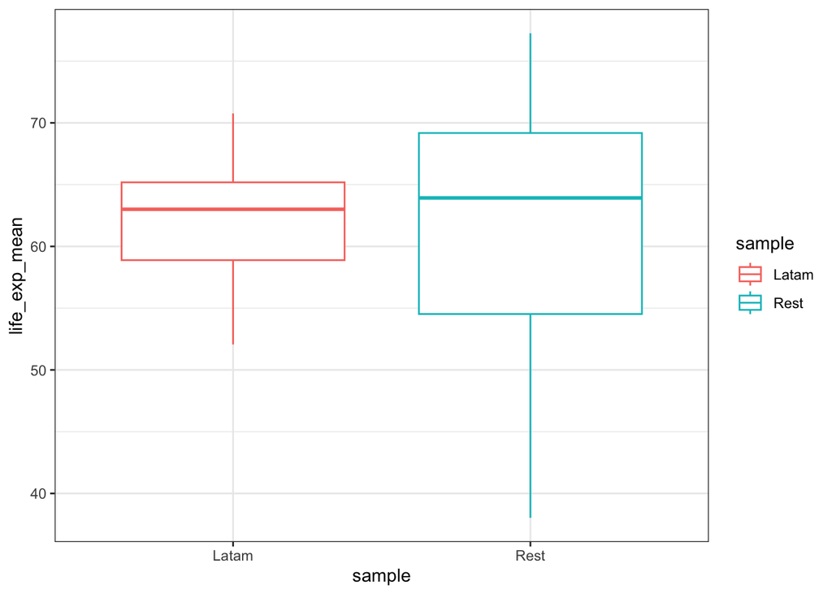

```r
ggplot(clean_life_expectancy_df_continent, aes(x = sample, y = life_exp_mean, color = sample)) +
  geom_boxplot() +
  theme_bw()
```

And this is the interpretation of a box plot.

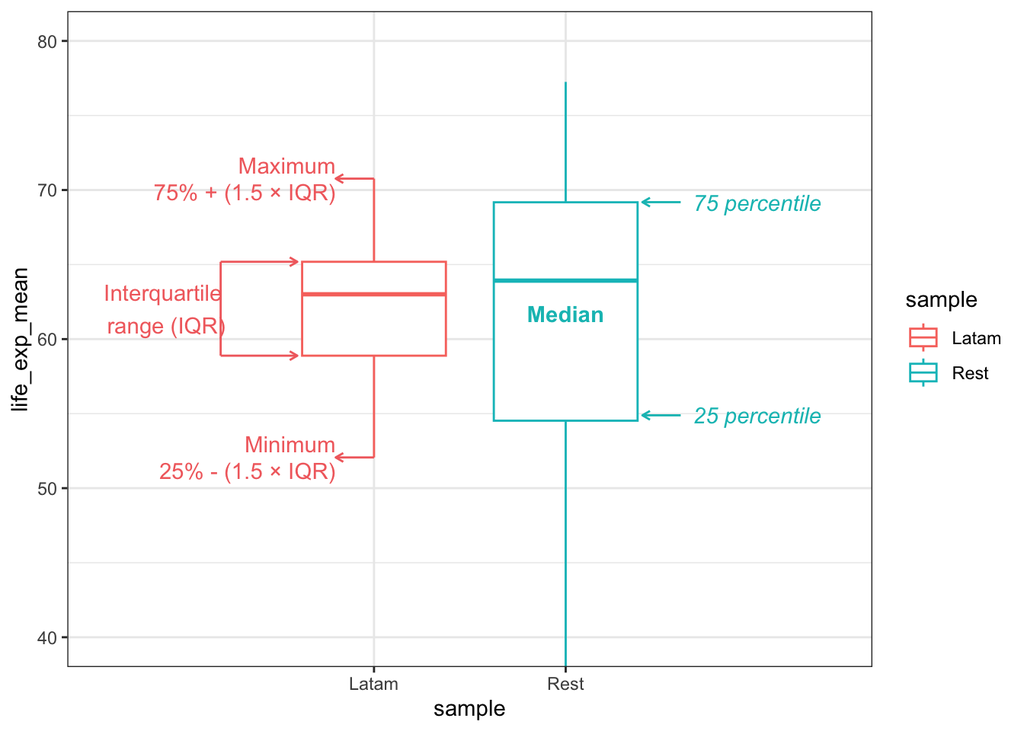

## 3.1 Comparing means - greater than a number

Now we can finally ask the question: Is the mean life expectancy in Latin America greater than the population life expectancy? What kind of test do we perform?

**Answer**: One-tailed z-test. This is because we are asking if something is “GREATER” than something else.

```r
library(BSDA)
z_obs_greater<-BSDA::z.test(latam_countries_df$life_exp_mean,
                     mu=mean_population, sigma.x=sd_population,
                     alternative = "greater")
z_obs_greater
```

```
    One-sample z-Test

data:  latam_countries_df$life_exp_mean
z = -0.011109, p-value = 0.5044
alternative hypothesis: true mean is greater than 61.93416
95 percent confidence interval:
 58.93453       NA
sample estimates:
mean of x
 61.91404
```

What is the Null Hypothesis for a one-tailed z-test?

The Null Hypothesis - $H_0$: The sample mean (for Latam) is not greater than the population mean.

What is the Alternative Hypothesis for a one-tailed z-test - $H_1$?

The Alternative Hypothesis - $H_1$: The sample mean (for Latam) is greater than the population mean.

Do we accept or reject the $H_0$?

We do not reject the null hypothesis (H0) because p ≥ 0.05 and conclude that the sample mean (for Latam) is not greater than the population mean.

## 3.2 Comparing means - less than a number

```r
z_obs_less<-BSDA::z.test(latam_countries_df$life_exp_mean,
                     mu=mean_population, sigma.x=sd_population,
                     alternative = "less")
z_obs_less
```

```
    One-sample z-Test

data:  latam_countries_df$life_exp_mean
z = -0.011109, p-value = 0.4956
alternative hypothesis: true mean is less than 61.93416
95 percent confidence interval:
       NA 64.89354
sample estimates:
mean of x
 61.91404
```

What is the Null Hypothesis for a one-tailed z-test?

The Null Hypothesis - $H_0$: The sample mean (for Latam) is NOT less than the population mean.

What is the Alternative Hypothesis for a one-tailed z-test - $H_1$?

The Alternative Hypothesis - $H_1$: The sample mean (for Latam) is less than the population mean.

Do we accept or reject the $H_0$?

We do not reject the null hypothesis (H0) because p ≥ 0.05 and conclude that the sample mean (for Latam) is not less than the population mean.

# 4 Z-Scores

As we discussed previously, the *standard normal distribution* is a special type of distribution with a mean $\mu = 0$ and a standard deviation $\sigma = 1$. For example, a z-score of 2 tells us that we are 2 standard deviations to the right of the mean.

A z-score allows to calculate how much area that specific score is associated with using the z-score table.

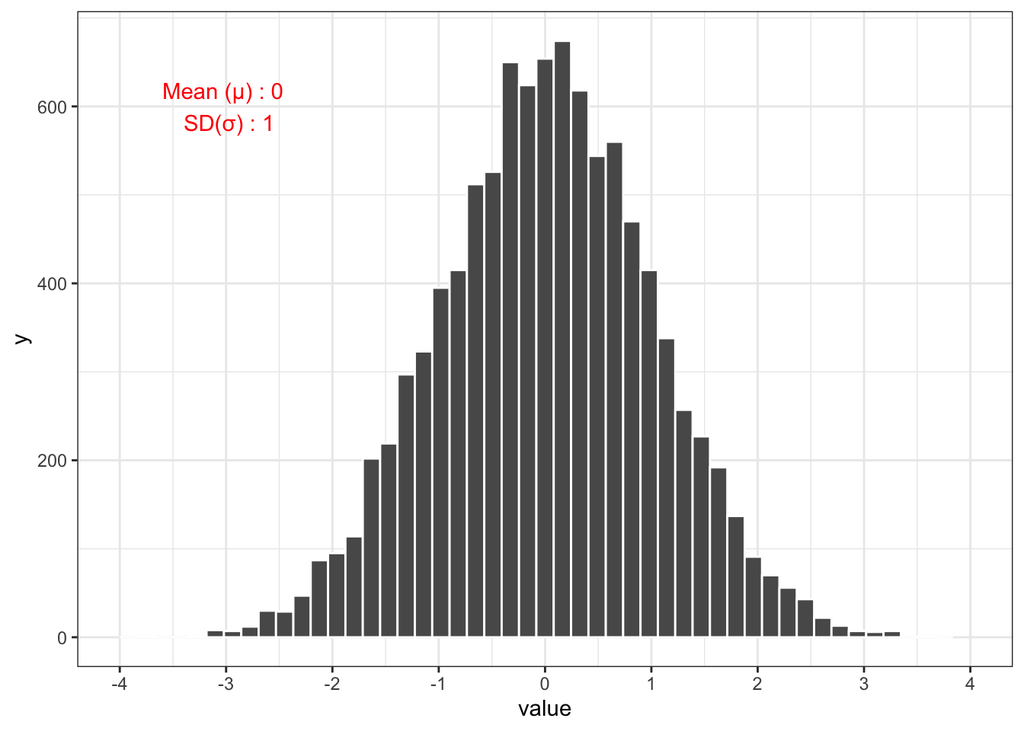

```r
#Generating 10000 obs.
generated_data_10000obs<-rnorm(10000, mean=0, sd=1)
#Turning them into a dataframe
generated_data_10000obs<-data.frame(generated_data_10000obs)
#Changing the variable names
names(generated_data_10000obs)<-"value"

#Adding notes to the graph using UTF-8 characters for the Greek letters
lines<- paste("Mean (\u03BC)", ": 0", "\n", "SD(\u03C3)", ": 1")


#Graphing
figure_5<-ggplot(data = generated_data_10000obs, aes(x=value))+
  geom_histogram(bins=50, col="white")+
  theme_bw()+
  scale_x_continuous(breaks=seq(-4, 4, by = 1), limits = c(-4,4))+
      annotate(geom="text",
           x=-3,
           y=600,
           label=lines,
           color="red")
figure_5
```

Each number on the X-axis (i.e. -4…4) corresponds to a z-score. A z-score tells us how many standard deviations an observation is from the mean $\mu$. A z-score also allows to calculate the area associated with that z-score is, based on a z-score table (standard normal table).

The cool thing about a standard normal distribution is that any normal distribution can be turned into a standard normal distribution with a mean $\mu$ of 0 and a standard distrubution $\sigma$ of 1. This process is called **standardization**.

The standardization formula:

$$z=\frac{x - \mu}{\sigma}$$
where: z - z-score x - observation $\mu$ - population mean $\sigma$ - population variance

# 5 Converting a distribution to a standard normal distribution

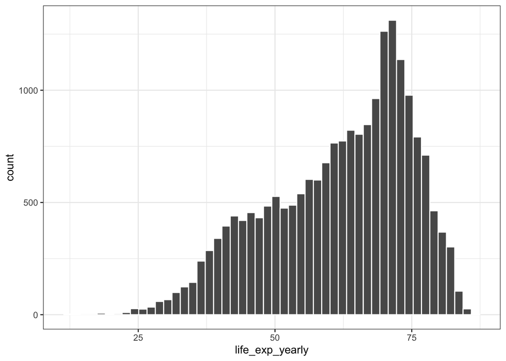

```r
#Step1: Loading the data
life_exp_df <- read.csv(file = './data/life-expectancy.csv')
#Step2: Creating more friendly column names
names(life_exp_df)[4]<-"life_exp_yearly"
#Step3: Graphing
figure_5<-ggplot(data = life_exp_df, aes(x=life_exp_yearly))+
      geom_histogram(bins=50, col="white")+
      theme_bw()
figure_5
```

Let us examine the first entries in our dataset:

```r
head(life_exp_df, n=10)
```

|  | Entity | Code | Year | life_exp_yearly |
| --- | --- | --- | --- | --- |
| 1 | Afghanistan | AFG | 1950 | 27.7 |
| 2 | Afghanistan | AFG | 1951 | 28.0 |
| 3 | Afghanistan | AFG | 1952 | 28.4 |
| 4 | Afghanistan | AFG | 1953 | 28.9 |
| 5 | Afghanistan | AFG | 1954 | 29.2 |
| 6 | Afghanistan | AFG | 1955 | 29.9 |
| 7 | Afghanistan | AFG | 1956 | 30.4 |
| 8 | Afghanistan | AFG | 1957 | 30.9 |
| 9 | Afghanistan | AFG | 1958 | 31.5 |
| 10 | Afghanistan | AFG | 1959 | 32.0 |

Let us now apply standardization to our dataset.

## 5.1 Step: Calculating the mean

```r
mean_life_exp<-mean(life_exp_df$life_exp_yearly, na.rm=T)
```

The mean for life expectancy throughout the world for the entire time series between 1543 and 2021 is 61.78. How come we have years that are lower than 1800? Let’s examine what the countries for which we have such long historical data are.

```r
historical_df_life_exp<-subset(life_exp_df, Year<1800)
unique(historical_df_life_exp$Entity)
```

```
[1] "Denmark"        "Europe"         "Finland"        "Sweden"
[5] "United Kingdom"
```

Thus, we can clearly see that our dataset contains detailed historical data on life expectancy for: Denmark, Europe, Finland, Sweden, United Kingdom. This is even more visible if we plot the time series for these countries prior to 1800s.

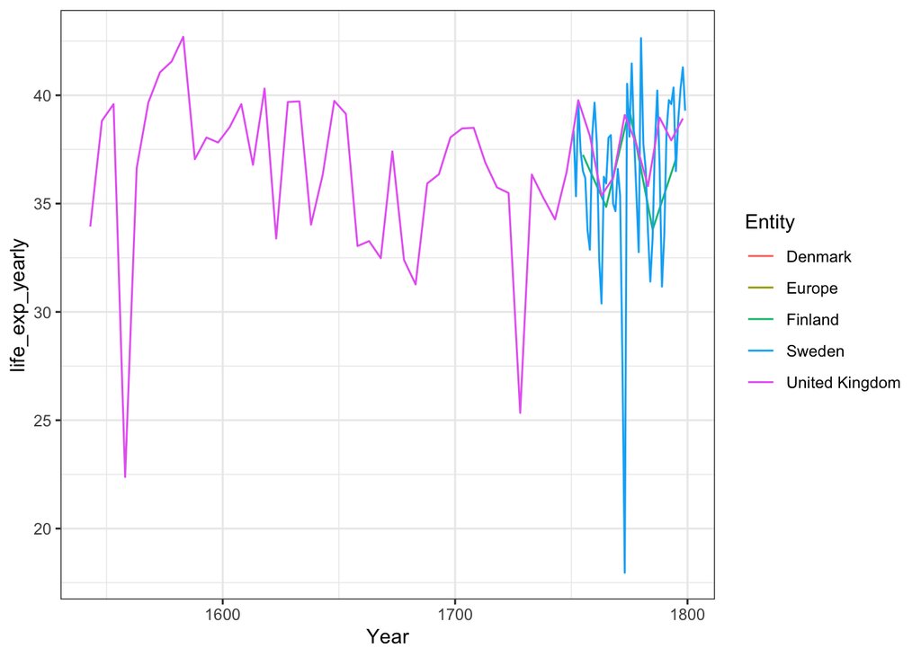

```r
figure_6<-ggplot(data = historical_df_life_exp, aes(x = Year, y = life_exp_yearly))+
  geom_line(aes(color = Entity))+
  theme_bw()
figure_6
```

So the graph shows us that we have the longest data for the UK.

## 5.2 Step: Calculating the variance

The next step entails calculating the variance of our dataset.

```r
sd_life_exp<-var(life_exp_df$life_exp_yearly, na.rm=T)
sd_life_exp
```

```
[1] 167.3311
```

Life expectancy has a variance of 167.3311413, and the standard deviation is 12.94.

## 5.3 Step: Applying the formula

We can now apply the formula:

$$z=\frac{x - \mu}{\sigma}$$

**Formula**

|  | Entity | Code | Year | life_exp_yearly | z_score |
| --- | --- | --- | --- | --- | --- |
| 1 | Afghanistan | AFG | 1950 | 27.7 | (life_expectancy - mean) / sd |
| 2 | Afghanistan | AFG | 1951 | 28.0 | (life_expectancy - mean) / sd |
| 3 | Afghanistan | AFG | 1952 | 28.4 | (life_expectancy - mean) / sd |
| 4 | Afghanistan | AFG | 1953 | 28.9 | (life_expectancy - mean) / sd |
| 5 | Afghanistan | AFG | 1954 | 29.2 | (life_expectancy - mean) / sd |
| 6 | Afghanistan | AFG | 1955 | 29.9 | (life_expectancy - mean) / sd |
| 7 | Afghanistan | AFG | 1956 | 30.4 | (life_expectancy - mean) / sd |
| 8 | Afghanistan | AFG | 1957 | 30.9 | (life_expectancy - mean) / sd |
| 9 | Afghanistan | AFG | 1958 | 31.5 | (life_expectancy - mean) / sd |
| 10 | Afghanistan | AFG | 1959 | 32.0 | (life_expectancy - mean) / sd |

**Result 1**

|  | Entity | Code | Year | life_exp_yearly | z_score |
| --- | --- | --- | --- | --- | --- |
| 1 | Afghanistan | AFG | 1950 | 27.7 | (27.7 - 61.78) / 167 |
| 2 | Afghanistan | AFG | 1951 | 28.0 | (28 - 61.78) / 167 |
| 3 | Afghanistan | AFG | 1952 | 28.4 | (28.4 - 61.78) / 167 |
| 4 | Afghanistan | AFG | 1953 | 28.9 | (28.9 - 61.78) / 167 |
| 5 | Afghanistan | AFG | 1954 | 29.2 | (29.2 - 61.78) / 167 |
| 6 | Afghanistan | AFG | 1955 | 29.9 | (29.9 - 61.78) / 167 |
| 7 | Afghanistan | AFG | 1956 | 30.4 | (30.4 - 61.78) / 167 |
| 8 | Afghanistan | AFG | 1957 | 30.9 | (30.9 - 61.78) / 167 |
| 9 | Afghanistan | AFG | 1958 | 31.5 | (31.5 - 61.78) / 167 |
| 10 | Afghanistan | AFG | 1959 | 32.0 | (32 - 61.78) / 167 |

**Result 2**

|  | Entity | Code | Year | life_exp_yearly | z_score |
| --- | --- | --- | --- | --- | --- |
| 1 | Afghanistan | AFG | 1950 | 27.7 | -0.2036959 |
| 2 | Afghanistan | AFG | 1951 | 28.0 | -0.2019030 |
| 3 | Afghanistan | AFG | 1952 | 28.4 | -0.1995126 |
| 4 | Afghanistan | AFG | 1953 | 28.9 | -0.1965245 |
| 5 | Afghanistan | AFG | 1954 | 29.2 | -0.1947316 |
| 6 | Afghanistan | AFG | 1955 | 29.9 | -0.1905483 |
| 7 | Afghanistan | AFG | 1956 | 30.4 | -0.1875602 |
| 8 | Afghanistan | AFG | 1957 | 30.9 | -0.1845721 |
| 9 | Afghanistan | AFG | 1958 | 31.5 | -0.1809864 |
| 10 | Afghanistan | AFG | 1959 | 32.0 | -0.1779983 |

Let’s do exactly that and inspect the first 10 entries:

```r
life_exp_df$z_score<-(life_exp_df$life_exp_yearly- mean_life_exp) / sd_life_exp
head(life_exp_df, n=10)
```

|  | Entity | Code | Year | life_exp_yearly | z_score |
| --- | --- | --- | --- | --- | --- |
| 1 | Afghanistan | AFG | 1950 | 27.7 | -0.2036959 |
| 2 | Afghanistan | AFG | 1951 | 28.0 | -0.2019030 |
| 3 | Afghanistan | AFG | 1952 | 28.4 | -0.1995126 |
| 4 | Afghanistan | AFG | 1953 | 28.9 | -0.1965245 |
| 5 | Afghanistan | AFG | 1954 | 29.2 | -0.1947316 |
| 6 | Afghanistan | AFG | 1955 | 29.9 | -0.1905483 |
| 7 | Afghanistan | AFG | 1956 | 30.4 | -0.1875602 |
| 8 | Afghanistan | AFG | 1957 | 30.9 | -0.1845721 |
| 9 | Afghanistan | AFG | 1958 | 31.5 | -0.1809864 |
| 10 | Afghanistan | AFG | 1959 | 32.0 | -0.1779983 |

# 6 Plotting the new distribution

We can now plot the new distribution:

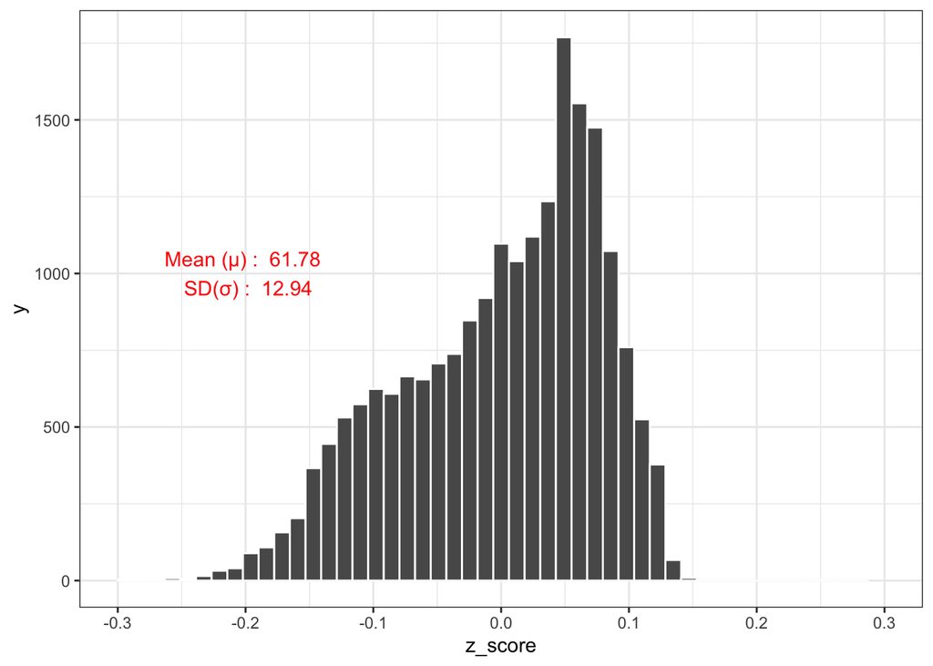

```r
#Adding notes to the graph
lines<- paste("Mean (\u03BC)", ": ", round(mean_life_exp, 2), "\n", "SD(\u03C3)", ": ", round(sd(life_exp_df$life_exp_yearly, na.rm=T), 2))

figure_7<-ggplot(data = life_exp_df, aes(x=z_score))+
  geom_histogram(bins=50, col="white")+
  theme_bw()+
  scale_x_continuous(breaks=seq(-0.3, 0.3, by = 0.1),
                     limits = c(-0.3, 0.3),
                     labels = scales::comma)+
      annotate(geom="text",
           x=-0.2,
           y=1000,
           label=lines,
           color="red")
figure_7
```

I used `scales::comma` option within `scale_x_continuous` to avoid scientific notation.

Let us now plot the two histograms side by side

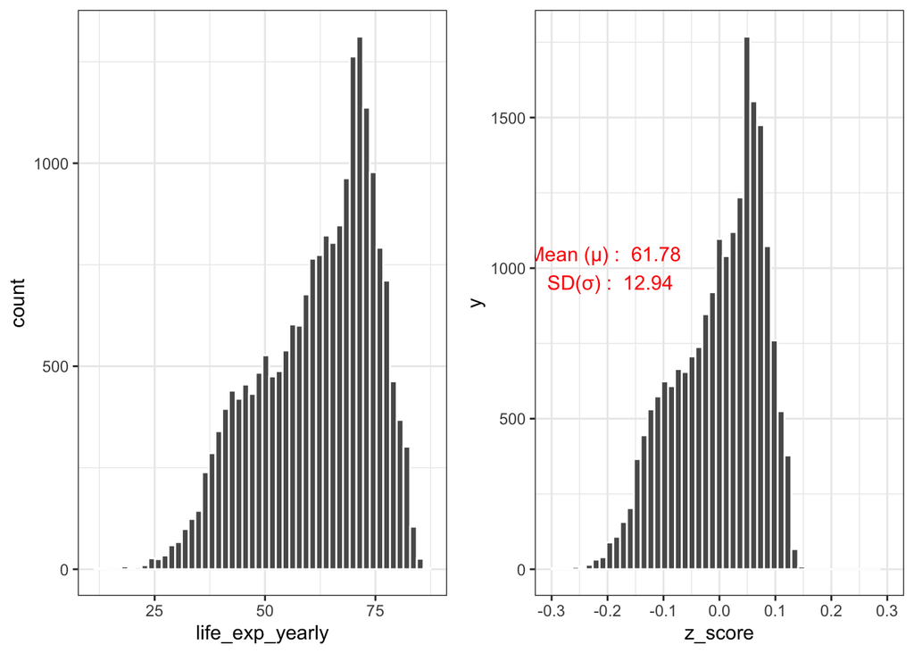

```r
grid.arrange(figure_5, figure_7, ncol=2)
```

We can see that the distributions are very similar. The logic is that if I plug in an x value of 50, that will get a z-score of -0.0704272. Similarly, if I plug an x value of 80, that will get a z-score of 0.108858.

# 7 Problem

Let us say that we were interested in the following problem: What is the proportion of countries where the life expectancy is lower than 50?

$P(X<50) = ?$

We first calculate the z-score. Remember a z-score is a number representing how many standard deviations above or below the mean population the score derived from a z-test is. Essentially, it is a numerical measurement that describes a value’s relationship to the mean of a group of values.

```r
z <-(50-mean_life_exp)/sd(life_expectancy_df2$life_exp_mean, na.rm=T)
z
```

```
[1] -1.363251
```

Note that is the empirical probability.

```r
ctry_50<-subset(life_expectancy_df2, life_exp_mean<50)
nrow(ctry_50)/nrow(life_expectancy_df2)
```

```
[1] 0.1171875
```

Thus we need to look for the proportion of z less than -1.36.

```r
xval<-pnorm(q=z, lower.tail=TRUE)
xval
```

```
[1] 0.08640166
```

Note that this is based on a theoretical probability.

Thus, the proportion countries where life expectancy is lower than 50 is 0.09.

# 8 Problem

You scored 72 in your last assignment. The class mean was 60 and standard deviation was 10. The grades follow a normal distribution. What is the probability that a randomly selected person in the class had a grade lower than yours?

The way we do that is the following:

```r
z <-(72-60)/10
xval<-pnorm(q=z, lower.tail=TRUE)
xval
```

```
[1] 0.8849303
```

What is the probability that a randomly selected person in the class had a grade higher than yours?

```r
1-xval
```

```
[1] 0.1150697
```